# Biostat 203B Homework 4

Due Mar 24 @ 11:59PM

Author

Fuchi Yang and 405727254

Load database libraries and the tidyverse frontend:

```r
suppressPackageStartupMessages(library(tidyverse))
suppressPackageStartupMessages(library(tidymodels))
suppressPackageStartupMessages(library(lubridate))
```

## 1 Predicting 30-day mortality

Using the ICU cohort `icu_cohort.rds` you built in Homework 3, develop at least three analytic approaches for predicting the 30-day mortality of patients admitted to ICU using demographic information (gender, age, marital status, ethnicity), first lab measurements during ICU stay, and first vital measurements during ICU stay. For example, you can use (1) logistic regression with elastic net (lasso + ridge) penalty (e.g., glmnet or keras package), (2) random forest, (3) boosting, and (4) support vector machines, or (5) MLP neural network (keras package)

```r
##load library##

library(GGally)
library(gtsummary)
library(tidyverse)
library(tidymodels)
library(ranger)
library(glmnet)
library(randomForest)
library(pROC)
library(stringr)
library(xgboost)
library(readr)
library(gtsummary)
library(dplyr)
options(java.parameters = "-Xmx10g")
```

1. Partition data into 50% training set and 50% test set. Stratify partitioning according the 30-day mortality status.

```r
##preprocess##
#read,select#
icu_cohort <- read_rds("mimic_icu_cohort.rds") %>%
   select(thirty_day_mort, marital_status, gender,ethnicity,Sodium, Glucose, Chloride, Potassium,      Creatinine, Hematocrit, Bicarbonate,
   WBC, Body_Temperature_Fahrenheit,
   Systolic_Non_Inactive_BP,
   Mean_Non_Inactive_BP,
   Respiratory_Rate,
   Heart_rate,
   Admission_age)
```

```r
##UNKNOWN TO NA##
icu_cohort$ethnicity[icu_cohort$ethnicity == 'UNKNOWN'] <- NA
icu_cohort$thirty_day_mort = as.factor(icu_cohort$thirty_day_mort)

##Temperature preprecoess##
icu_cohort$Body_Temperature_Fahrenheit[icu_cohort$Body_Temperature_Fahrenheit > 45
                                  & icu_cohort$Body_Temperature_Fahrenheit < 90
                                  & !is.na(icu_cohort$Body_Temperature_Fahrenheit)] <- NA
icu_cohort$Body_Temperature_Fahrenheit[icu_cohort$Body_Temperature_Fahrenheit <= 34
                                       & !is.na(icu_cohort$Body_Temperature_Fahrenheit)] <- NA
icu_cohort$Body_Temperature_Fahrenheit[icu_cohort$Body_Temperature_Fahrenheit > 34
                                  & icu_cohort$Body_Temperature_Fahrenheit <= 45 &
                                    !is.na(icu_cohort$Body_Temperature_Fahrenheit)] <-
icu_cohort$Body_Temperature_Fahrenheit * 9 / 5 + 32
icu_cohort$Body_Temperature_Fahrenheit[icu_cohort$Body_Temperature_Fahrenheit >= 115
                            & !is.na(icu_cohort$Body_Temperature_Fahrenheit)] <- NA
```

```r
#
icu_cohort %>% tbl_summary(by =thirty_day_mort)
```

| **Characteristic** | **FALSE**, N = 47,714<sup>1</sup> | **TRUE**, N = 5,436<sup>1</sup> |
| --- | --- | --- |
| marital_status |  |  |
| DIVORCED | 3,384 (7.7%) | 311 (7.1%) |
| MARRIED | 21,982 (50%) | 2,130 (49%) |
| SINGLE | 13,187 (30%) | 1,055 (24%) |
| WIDOWED | 5,578 (13%) | 892 (20%) |
| Unknown | 3,583 | 1,048 |
| gender |  |  |
| F | 20,847 (44%) | 2,506 (46%) |
| M | 26,867 (56%) | 2,930 (54%) |
| ethnicity |  |  |
| AMERICAN INDIAN/ALASKA NATIVE | 86 (0.2%) | 8 (0.2%) |
| ASIAN | 1,392 (3.2%) | 172 (4.0%) |
| BLACK/AFRICAN AMERICAN | 4,472 (10%) | 402 (9.4%) |
| HISPANIC/LATINO | 1,707 (4.0%) | 120 (2.8%) |
| OTHER | 2,321 (5.4%) | 216 (5.0%) |
| UNABLE TO OBTAIN | 635 (1.5%) | 124 (2.9%) |
| WHITE | 32,431 (75%) | 3,237 (76%) |
| Unknown | 4,670 | 1,157 |
| Sodium | 140.0 (138.0, 143.0) | 142.0 (138.0, 147.0) |
| Unknown | 1,320 | 432 |
| Glucose | 141 (115, 181) | 184 (143, 258) |
| Unknown | 1,429 | 446 |
| Chloride | 107 (104, 110) | 108 (103, 113) |
| Unknown | 1,318 | 435 |
| Potassium | 4.40 (4.10, 4.80) | 4.80 (4.30, 5.40) |
| Unknown | 1,319 | 433 |
| Creatinine | 1.00 (0.80, 1.40) | 1.70 (1.00, 3.00) |
| Unknown | 1,330 | 442 |
| Hematocrit | 34.3 (30.7, 38.3) | 33.7 (29.6, 38.3) |
| Unknown | 1,387 | 454 |
| Bicarbonate | 26.0 (23.0, 28.0) | 24.0 (20.0, 28.0) |
| Unknown | 1,338 | 442 |
| WBC | 12 (9, 17) | 16 (11, 23) |
| Unknown | 1,525 | 463 |
| Body_Temperature_Fahrenheit | 99.10 (98.60, 100.00) | 99.60 (98.60, 101.20) |
| Unknown | 521 | 517 |
| Systolic_Non_Inactive_BP | 148 (132, 165) | 147 (129, 167) |
| Unknown | 421 | 262 |
| Mean_Non_Inactive_BP | 103 (91, 118) | 103 (89, 119) |
| Unknown | 444 | 260 |
| Respiratory_Rate | 29 (25, 34) | 33 (28, 38) |
| Unknown | 54 | 8 |
| Heart_rate | 104 (92, 120) | 122 (105, 139) |
| Unknown | 13 | 2 |
| Admission_age | 64 (52, 76) | 73 (61, 83) |

<sup>1</sup> n (%); Median (IQR)

2. Train and tune the models using the training set.

```r
##split train test##
set.seed(8)

ICU_split <- initial_split(
  icu_cohort,
  strata = "thirty_day_mort",
  prop = 0.5
)

ICU_Train <- training(ICU_split)
ICU_Test <- testing(ICU_split)

##5CV##
set.seed(8)
folds <- vfold_cv(ICU_Train, v = 5)
folds
```

```
#  5-fold cross-validation
# A tibble: 5 × 2
  splits               id
  <list>               <chr>
1 <split [21260/5315]> Fold1
2 <split [21260/5315]> Fold2
3 <split [21260/5315]> Fold3
4 <split [21260/5315]> Fold4
5 <split [21260/5315]> Fold5
```

```r
###RF###
rf_recipe <-
  recipe(
    thirty_day_mort ~ .,
    data = ICU_Train
  ) %>%
  # mean and mode imputation
  step_impute_mode( marital_status, ethnicity) %>%
  step_impute_mean("Sodium", "Glucose", "Chloride", "Potassium", "Creatinine",
                   "Hematocrit", "Bicarbonate",
                   "WBC", "Body_Temperature_Fahrenheit",
                   "Systolic_Non_Inactive_BP",
                   "Mean_Non_Inactive_BP",
                   "Respiratory_Rate",
                   "Heart_rate") %>%
  # create traditional dummy variables
  step_dummy(all_nominal_predictors()) %>%
  # zero-variance filter
  step_zv(all_numeric_predictors()) %>%
  # center and scale numeric data
  #step_normalize(all_numeric_predictors()) %>%
  # estimate the means and standard deviations
  prep(training = ICU_Train, retain = TRUE)
rf_recipe

rf_model <-
  rand_forest(
    mode = "classification",
    # Number of predictors randomly sampled in each split
    mtry = tune(),
    # Number of trees in ensemble
    trees = tune()
  ) %>%
  set_engine("ranger")

rf_wf <- workflow() %>%
  add_recipe(rf_recipe) %>%
  add_model(rf_model)
rf_wf
```

```
══ Workflow ════════════════════════════════════════════════════════════════════
Preprocessor: Recipe
Model: rand_forest()

── Preprocessor ────────────────────────────────────────────────────────────────
4 Recipe Steps

• step_impute_mode()
• step_impute_mean()
• step_dummy()
• step_zv()

── Model ───────────────────────────────────────────────────────────────────────
Random Forest Model Specification (classification)

Main Arguments:
  mtry = tune()
  trees = tune()

Computational engine: ranger
```

```r
param_grid <- grid_regular(
  trees(range = c(100L, 300L)),
  mtry(range = c(1L, 5L)),
  levels = c(3, 5)
)
param_grid
```

```
# A tibble: 15 × 2
   trees  mtry
   <int> <int>
 1   100     1
 2   200     1
 3   300     1
 4   100     2
 5   200     2
 6   300     2
 7   100     3
 8   200     3
 9   300     3
10   100     4
11   200     4
12   300     4
13   100     5
14   200     5
15   300     5
```

```r
##RF_fit##
rf_fit <- rf_wf %>%
  tune_grid(
    resamples = folds,
    grid = param_grid,
    metrics = metric_set(roc_auc, accuracy)
  )
rf_fit
```

```
# Tuning results
# 5-fold cross-validation
# A tibble: 5 × 4
  splits               id    .metrics          .notes
  <list>               <chr> <list>            <list>
1 <split [21260/5315]> Fold1 <tibble [30 × 6]> <tibble [0 × 3]>
2 <split [21260/5315]> Fold2 <tibble [30 × 6]> <tibble [0 × 3]>
3 <split [21260/5315]> Fold3 <tibble [30 × 6]> <tibble [0 × 3]>
4 <split [21260/5315]> Fold4 <tibble [30 × 6]> <tibble [0 × 3]>
5 <split [21260/5315]> Fold5 <tibble [30 × 6]> <tibble [0 × 3]>
```

```
# A tibble: 30 × 8
    mtry trees .metric  .estimator  mean     n std_err .config
   <int> <int> <chr>    <chr>      <dbl> <int>   <dbl> <chr>
 1     1   100 accuracy binary     0.898     5 0.00216 Preprocessor1_Model01
 2     1   100 roc_auc  binary     0.859     5 0.00332 Preprocessor1_Model01
 3     1   200 accuracy binary     0.898     5 0.00219 Preprocessor1_Model02
 4     1   200 roc_auc  binary     0.860     5 0.00266 Preprocessor1_Model02
 5     1   300 accuracy binary     0.898     5 0.00218 Preprocessor1_Model03
 6     1   300 roc_auc  binary     0.862     5 0.00286 Preprocessor1_Model03
 7     2   100 accuracy binary     0.910     5 0.00188 Preprocessor1_Model04
 8     2   100 roc_auc  binary     0.871     5 0.00131 Preprocessor1_Model04
 9     2   200 accuracy binary     0.910     5 0.00198 Preprocessor1_Model05
10     2   200 roc_auc  binary     0.873     5 0.00238 Preprocessor1_Model05
# … with 20 more rows
```

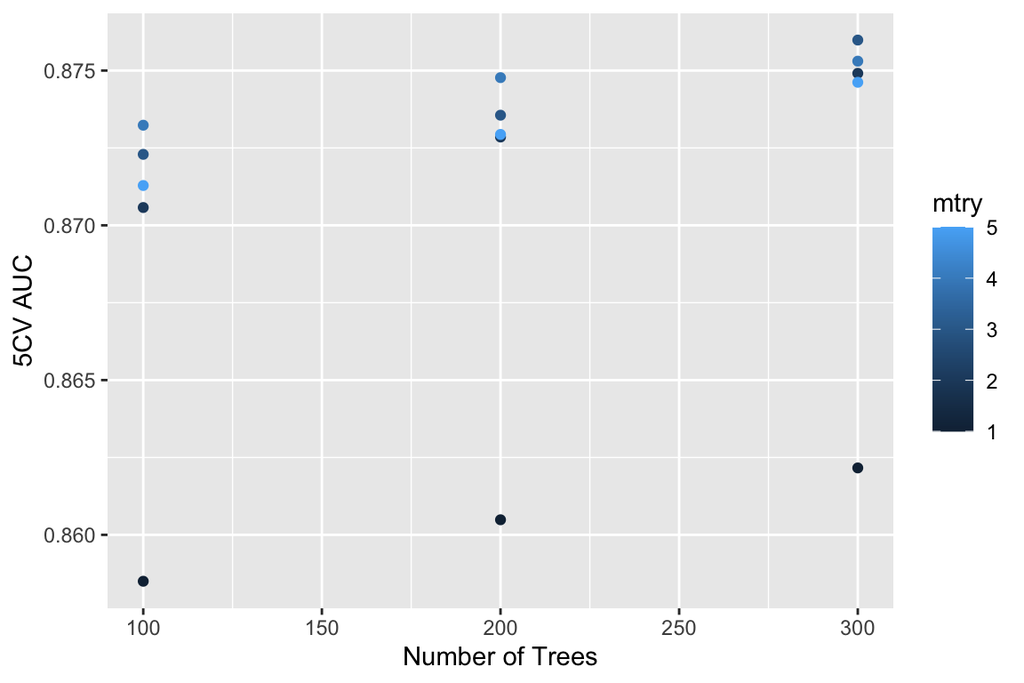

```r
rf_fit %>%
  collect_metrics() %>%
  print(width = Inf) %>%
  filter(.metric == "roc_auc") %>%
  ggplot(mapping = aes(x = trees, y = mean, color = mtry)) +
  geom_point() +
  # geom_line() +
  labs(x = "Number of Trees", y = "5CV AUC")
```

```r
rf_fit %>%
  show_best("roc_auc")
```

```
# A tibble: 5 × 8
   mtry trees .metric .estimator  mean     n std_err .config
  <int> <int> <chr>   <chr>      <dbl> <int>   <dbl> <chr>
1     3   300 roc_auc binary     0.876     5 0.00115 Preprocessor1_Model09
2     4   300 roc_auc binary     0.875     5 0.00178 Preprocessor1_Model12
3     2   300 roc_auc binary     0.875     5 0.00192 Preprocessor1_Model06
4     4   200 roc_auc binary     0.875     5 0.00141 Preprocessor1_Model11
5     5   300 roc_auc binary     0.875     5 0.00138 Preprocessor1_Model15
```

```r
rf_fit
```

```
# Tuning results
# 5-fold cross-validation
# A tibble: 5 × 4
  splits               id    .metrics          .notes
  <list>               <chr> <list>            <list>
1 <split [21260/5315]> Fold1 <tibble [30 × 6]> <tibble [0 × 3]>
2 <split [21260/5315]> Fold2 <tibble [30 × 6]> <tibble [0 × 3]>
3 <split [21260/5315]> Fold3 <tibble [30 × 6]> <tibble [0 × 3]>
4 <split [21260/5315]> Fold4 <tibble [30 × 6]> <tibble [0 × 3]>
5 <split [21260/5315]> Fold5 <tibble [30 × 6]> <tibble [0 × 3]>
```

```r
best_rf <- rf_fit %>%
  select_best("roc_auc")
best_rf
```

```
# A tibble: 1 × 3
   mtry trees .config
  <int> <int> <chr>
1     3   300 Preprocessor1_Model09
```

```r
final_wf <- rf_wf %>%
  finalize_workflow(best_rf)
final_wf
```

```
══ Workflow ════════════════════════════════════════════════════════════════════
Preprocessor: Recipe
Model: rand_forest()

── Preprocessor ────────────────────────────────────────────────────────────────
4 Recipe Steps

• step_impute_mode()
• step_impute_mean()
• step_dummy()
• step_zv()

── Model ───────────────────────────────────────────────────────────────────────
Random Forest Model Specification (classification)

Main Arguments:
  mtry = 3
  trees = 300

Computational engine: ranger
```

```r
final_fit <-
  final_wf %>%
  last_fit(ICU_split)
final_fit
```

```
# Resampling results
# Manual resampling
# A tibble: 1 × 6
  splits                id               .metrics .notes   .predict…¹ .workflow
  <list>                <chr>            <list>   <list>   <list>     <list>
1 <split [26575/26575]> train/test split <tibble> <tibble> <tibble>   <workflow>
# … with abbreviated variable name ¹.predictions
```

```r
final_fit %>%
  collect_metrics()
```

```
# A tibble: 2 × 4
  .metric  .estimator .estimate .config
  <chr>    <chr>          <dbl> <chr>
1 accuracy binary         0.913 Preprocessor1_Model1
2 roc_auc  binary         0.874 Preprocessor1_Model1
```

```r
####SVM####
logit_recipe <-
  recipe(
    thirty_day_mort ~ .,
    data = ICU_Train
  ) %>%
  step_impute_mode( marital_status, ethnicity) %>%
  step_impute_mean("Sodium", "Glucose", "Chloride", "Potassium", "Creatinine",
                   "Hematocrit", "Bicarbonate",
                   "WBC", "Body_Temperature_Fahrenheit",
                   "Systolic_Non_Inactive_BP",
                   "Mean_Non_Inactive_BP",
                   "Respiratory_Rate",
                   "Heart_rate") %>%
  # create traditional dummy variables (necessary for svm)
  step_dummy(all_nominal_predictors()) %>%
  # zero-variance filter
  step_zv(all_numeric_predictors()) %>%
  # center and scale numeric data
  step_normalize(all_numeric_predictors()) %>%
  # estimate the means and standard deviations
  prep(training = ICU_Train, retain = TRUE)
logit_recipe

logit_model <-
  logistic_reg(
    penalty = tune(),
    mixture = tune()
  ) %>%
  set_engine("glmnet", standardize = FALSE)
logit_model
```

```
Logistic Regression Model Specification (classification)

Main Arguments:
  penalty = tune()
  mixture = tune()

Engine-Specific Arguments:
  standardize = FALSE

Computational engine: glmnet
```

```r
logit_wf <- workflow() %>%
  add_recipe(logit_recipe) %>%
  add_model(logit_model)
logit_wf
```

```
══ Workflow ════════════════════════════════════════════════════════════════════
Preprocessor: Recipe
Model: logistic_reg()

── Preprocessor ────────────────────────────────────────────────────────────────
5 Recipe Steps

• step_impute_mode()
• step_impute_mean()
• step_dummy()
• step_zv()
• step_normalize()

── Model ───────────────────────────────────────────────────────────────────────
Logistic Regression Model Specification (classification)

Main Arguments:
  penalty = tune()
  mixture = tune()

Engine-Specific Arguments:
  standardize = FALSE

Computational engine: glmnet
```

```r
param_grid <- grid_regular(
  penalty(range = c(-6, 3)),
  mixture(),
  levels = c(100, 5)
)
param_grid
```

```
# A tibble: 500 × 2
      penalty mixture
        <dbl>   <dbl>
 1 0.000001         0
 2 0.00000123       0
 3 0.00000152       0
 4 0.00000187       0
 5 0.00000231       0
 6 0.00000285       0
 7 0.00000351       0
 8 0.00000433       0
 9 0.00000534       0
10 0.00000658       0
# … with 490 more rows
```

```r
logit_fit <- logit_wf %>%
  tune_grid(
    resamples = folds,
    grid = param_grid,
    metrics = metric_set(roc_auc, accuracy)
  )
logit_fit
```

```
# Tuning results
# 5-fold cross-validation
# A tibble: 5 × 4
  splits               id    .metrics             .notes
  <list>               <chr> <list>               <list>
1 <split [21260/5315]> Fold1 <tibble [1,000 × 6]> <tibble [0 × 3]>
2 <split [21260/5315]> Fold2 <tibble [1,000 × 6]> <tibble [0 × 3]>
3 <split [21260/5315]> Fold3 <tibble [1,000 × 6]> <tibble [0 × 3]>
4 <split [21260/5315]> Fold4 <tibble [1,000 × 6]> <tibble [0 × 3]>
5 <split [21260/5315]> Fold5 <tibble [1,000 × 6]> <tibble [0 × 3]>
```

```
# A tibble: 1,000 × 8
      penalty mixture .metric  .estimator  mean     n std_err
        <dbl>   <dbl> <chr>    <chr>      <dbl> <int>   <dbl>
 1 0.000001         0 accuracy binary     0.900     5 0.00171
 2 0.000001         0 roc_auc  binary     0.782     5 0.00336
 3 0.00000123       0 accuracy binary     0.900     5 0.00171
 4 0.00000123       0 roc_auc  binary     0.782     5 0.00336
 5 0.00000152       0 accuracy binary     0.900     5 0.00171
 6 0.00000152       0 roc_auc  binary     0.782     5 0.00336
 7 0.00000187       0 accuracy binary     0.900     5 0.00171
 8 0.00000187       0 roc_auc  binary     0.782     5 0.00336
 9 0.00000231       0 accuracy binary     0.900     5 0.00171
10 0.00000231       0 roc_auc  binary     0.782     5 0.00336
   .config
   <chr>
 1 Preprocessor1_Model001
 2 Preprocessor1_Model001
 3 Preprocessor1_Model002
 4 Preprocessor1_Model002
 5 Preprocessor1_Model003
 6 Preprocessor1_Model003
 7 Preprocessor1_Model004
 8 Preprocessor1_Model004
 9 Preprocessor1_Model005
10 Preprocessor1_Model005
# … with 990 more rows
```

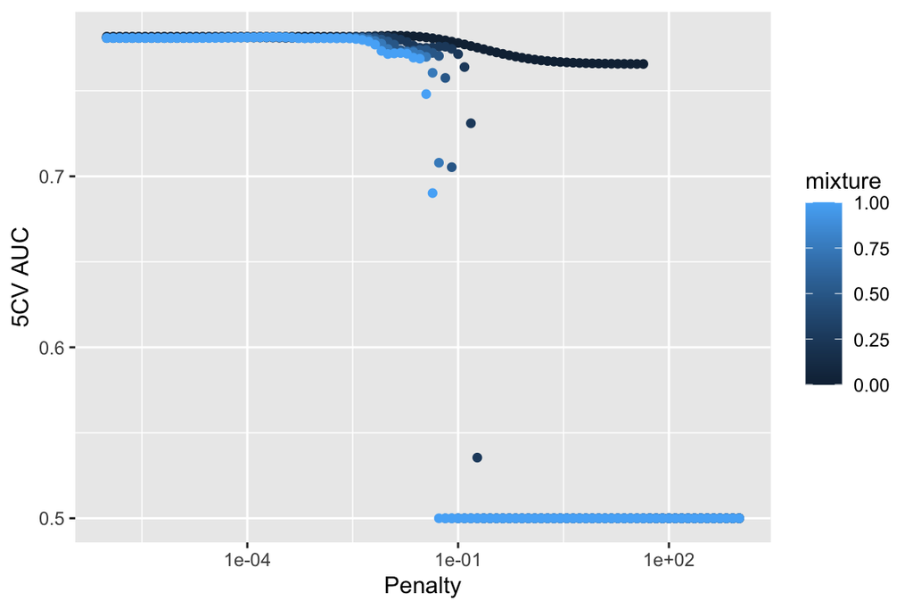

```r
logit_fit %>%
  collect_metrics() %>%
  print(width = Inf) %>%
  filter(.metric == "roc_auc") %>%
  ggplot(mapping = aes(x = penalty, y = mean, color = mixture)) +
  geom_point() +
  labs(x = "Penalty", y = "5CV AUC") +
  scale_x_log10()
```

```r
logit_fit %>%
  show_best("roc_auc")
```

```
# A tibble: 5 × 8
  penalty mixture .metric .estimator  mean     n std_err .config
    <dbl>   <dbl> <chr>   <chr>      <dbl> <int>   <dbl> <chr>
1 0.0123        0 roc_auc binary     0.782     5 0.00354 Preprocessor1_Model046
2 0.0152        0 roc_auc binary     0.782     5 0.00359 Preprocessor1_Model047
3 0.01          0 roc_auc binary     0.782     5 0.00352 Preprocessor1_Model045
4 0.00811       0 roc_auc binary     0.782     5 0.00348 Preprocessor1_Model044
5 0.0187        0 roc_auc binary     0.782     5 0.00363 Preprocessor1_Model048
```

```r
best_logit <- logit_fit %>%
  select_best("roc_auc")
best_logit
```

```
# A tibble: 1 × 3
  penalty mixture .config
    <dbl>   <dbl> <chr>
1  0.0123       0 Preprocessor1_Model046
```

```r
# Final workflow
final_wf <- logit_wf %>%
  finalize_workflow(best_logit)
final_wf
```

```
══ Workflow ════════════════════════════════════════════════════════════════════
Preprocessor: Recipe
Model: logistic_reg()

── Preprocessor ────────────────────────────────────────────────────────────────
5 Recipe Steps

• step_impute_mode()
• step_impute_mean()
• step_dummy()
• step_zv()
• step_normalize()

── Model ───────────────────────────────────────────────────────────────────────
Logistic Regression Model Specification (classification)

Main Arguments:
  penalty = 0.0123284673944207
  mixture = 0

Engine-Specific Arguments:
  standardize = FALSE

Computational engine: glmnet
```

```r
final_fit <-
  final_wf %>%
  last_fit(ICU_split)
final_fit
```

```
# Resampling results
# Manual resampling
# A tibble: 1 × 6
  splits                id               .metrics .notes   .predict…¹ .workflow
  <list>                <chr>            <list>   <list>   <list>     <list>
1 <split [26575/26575]> train/test split <tibble> <tibble> <tibble>   <workflow>
# … with abbreviated variable name ¹.predictions
```

```r
final_fit %>%
  collect_metrics()
```

```
# A tibble: 2 × 4
  .metric  .estimator .estimate .config
  <chr>    <chr>          <dbl> <chr>
1 accuracy binary         0.900 Preprocessor1_Model1
2 roc_auc  binary         0.777 Preprocessor1_Model1
```

```r
gb_recipe <-
  recipe(
    thirty_day_mort ~ .,
    data = ICU_Train
  ) %>%
  step_impute_mode( marital_status, ethnicity) %>%
  step_impute_mean("Sodium", "Glucose", "Chloride", "Potassium", "Creatinine",
                   "Hematocrit", "Bicarbonate",
                   "WBC", "Body_Temperature_Fahrenheit",
                   "Systolic_Non_Inactive_BP",
                   "Mean_Non_Inactive_BP",
                   "Respiratory_Rate",
                   "Heart_rate") %>%  # create traditional dummy variables
  step_dummy(all_nominal_predictors()) %>%
  # zero-variance filter
  step_zv(all_numeric_predictors()) %>%
  # center and scale numeric data
  #step_normalize(all_numeric_predictors()) %>%
  # estimate the means and standard deviations
  prep(training = ICU_Train, retain = TRUE)

gb_recipe

gb_model <-
  boost_tree(
    mode = "classification",
    trees = 1000,
    tree_depth = tune(),
    learn_rate = tune()
  ) %>%
  set_engine("xgboost")
gb_model
```

```
Boosted Tree Model Specification (classification)

Main Arguments:
  trees = 1000
  tree_depth = tune()
  learn_rate = tune()

Computational engine: xgboost
```

```r
gb_wf <- workflow() %>%
  add_recipe(gb_recipe) %>%
  add_model(gb_model)
gb_wf
```

```
══ Workflow ════════════════════════════════════════════════════════════════════
Preprocessor: Recipe
Model: boost_tree()

── Preprocessor ────────────────────────────────────────────────────────────────
4 Recipe Steps

• step_impute_mode()
• step_impute_mean()
• step_dummy()
• step_zv()

── Model ───────────────────────────────────────────────────────────────────────
Boosted Tree Model Specification (classification)

Main Arguments:
  trees = 1000
  tree_depth = tune()
  learn_rate = tune()

Computational engine: xgboost
```

```r
param_grid <- grid_regular(
  tree_depth(range = c(1L, 3L)),
  learn_rate(range = c(-5, 2), trans = log10_trans()),
  levels = c(3, 10)
  )
param_grid
```

```
# A tibble: 30 × 2
   tree_depth learn_rate
        <int>      <dbl>
 1          1  0.00001
 2          2  0.00001
 3          3  0.00001
 4          1  0.0000599
 5          2  0.0000599
 6          3  0.0000599
 7          1  0.000359
 8          2  0.000359
 9          3  0.000359
10          1  0.00215
# … with 20 more rows
```

```r
set.seed(8)

gb_fit <- gb_wf %>%
  tune_grid(
    resamples = folds,
    grid = param_grid,
    metrics = metric_set(roc_auc, accuracy)
    )
gb_fit
```

```
# Tuning results
# 5-fold cross-validation
# A tibble: 5 × 4
  splits               id    .metrics          .notes
  <list>               <chr> <list>            <list>
1 <split [21260/5315]> Fold1 <tibble [60 × 6]> <tibble [0 × 3]>
2 <split [21260/5315]> Fold2 <tibble [60 × 6]> <tibble [0 × 3]>
3 <split [21260/5315]> Fold3 <tibble [60 × 6]> <tibble [0 × 3]>
4 <split [21260/5315]> Fold4 <tibble [60 × 6]> <tibble [0 × 3]>
5 <split [21260/5315]> Fold5 <tibble [60 × 6]> <tibble [0 × 3]>
```

```
# A tibble: 60 × 8
   tree_depth learn_rate .metric  .estimator  mean     n std_err
        <int>      <dbl> <chr>    <chr>      <dbl> <int>   <dbl>
 1          1  0.00001   accuracy binary     0.898     5 0.00217
 2          1  0.00001   roc_auc  binary     0.676     5 0.00622
 3          2  0.00001   accuracy binary     0.899     5 0.00232
 4          2  0.00001   roc_auc  binary     0.720     5 0.00648
 5          3  0.00001   accuracy binary     0.900     5 0.00201
 6          3  0.00001   roc_auc  binary     0.748     5 0.00264
 7          1  0.0000599 accuracy binary     0.898     5 0.00217
 8          1  0.0000599 roc_auc  binary     0.676     5 0.00622
 9          2  0.0000599 accuracy binary     0.899     5 0.00232
10          2  0.0000599 roc_auc  binary     0.730     5 0.00474
   .config
   <chr>
 1 Preprocessor1_Model01
 2 Preprocessor1_Model01
 3 Preprocessor1_Model02
 4 Preprocessor1_Model02
 5 Preprocessor1_Model03
 6 Preprocessor1_Model03
 7 Preprocessor1_Model04
 8 Preprocessor1_Model04
 9 Preprocessor1_Model05
10 Preprocessor1_Model05
# … with 50 more rows
```

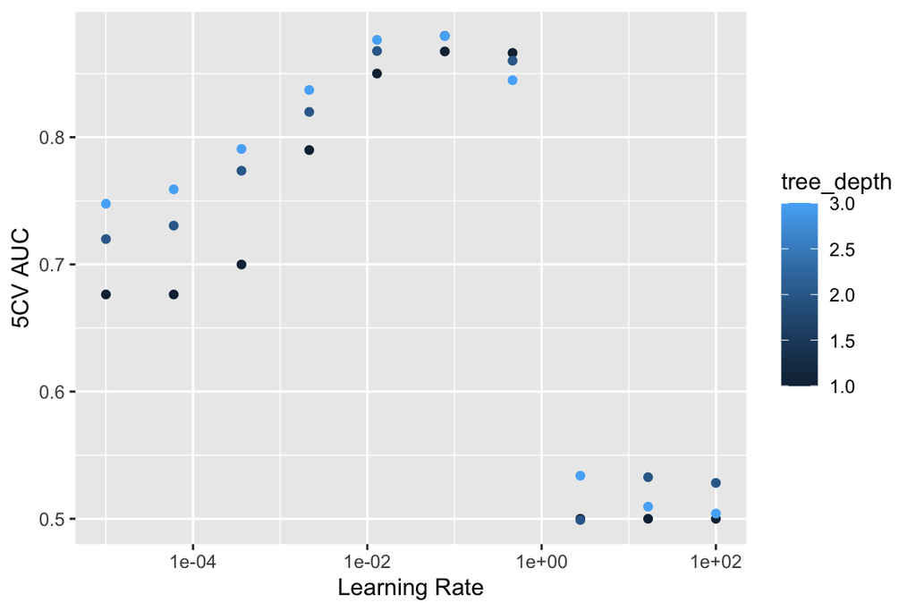

```r
gb_fit %>%
  collect_metrics() %>%
  print(width = Inf) %>%
  filter(.metric == "roc_auc") %>%
  ggplot(mapping = aes(x = learn_rate, y = mean, color = tree_depth)) +
  geom_point() +
  labs(x = "Learning Rate", y = "5CV AUC") +
  scale_x_log10()
```

```r
gb_fit %>%
  show_best("roc_auc")
```

```
# A tibble: 5 × 8
  tree_depth learn_rate .metric .estimator  mean     n  std_err .config
       <int>      <dbl> <chr>   <chr>      <dbl> <int>    <dbl> <chr>
1          2     0.0774 roc_auc binary     0.880     5 0.00175  Preprocessor1_M…
2          3     0.0774 roc_auc binary     0.880     5 0.000981 Preprocessor1_M…
3          3     0.0129 roc_auc binary     0.877     5 0.00224  Preprocessor1_M…
4          2     0.0129 roc_auc binary     0.868     5 0.00252  Preprocessor1_M…
5          1     0.0774 roc_auc binary     0.867     5 0.00288  Preprocessor1_M…
```

```r
best_gb <- gb_fit %>%
  select_best("roc_auc")
best_gb
```

```
# A tibble: 1 × 3
  tree_depth learn_rate .config
       <int>      <dbl> <chr>
1          2     0.0774 Preprocessor1_Model17
```

```r
# Final workflow
final_wf <- gb_wf %>%
  finalize_workflow(best_gb)
final_wf
```

```
══ Workflow ════════════════════════════════════════════════════════════════════
Preprocessor: Recipe
Model: boost_tree()

── Preprocessor ────────────────────────────────────────────────────────────────
4 Recipe Steps

• step_impute_mode()
• step_impute_mean()
• step_dummy()
• step_zv()

── Model ───────────────────────────────────────────────────────────────────────
Boosted Tree Model Specification (classification)

Main Arguments:
  trees = 1000
  tree_depth = 2
  learn_rate = 0.0774263682681127

Computational engine: xgboost
```

```r
final_fit <-
  final_wf %>%
  last_fit(ICU_split)
final_fit
```

```
# Resampling results
# Manual resampling
# A tibble: 1 × 6
  splits                id               .metrics .notes   .predict…¹ .workflow
  <list>                <chr>            <list>   <list>   <list>     <list>
1 <split [26575/26575]> train/test split <tibble> <tibble> <tibble>   <workflow>
# … with abbreviated variable name ¹.predictions
```

```r
final_fit %>%
  collect_metrics()
```

```
# A tibble: 2 × 4
  .metric  .estimator .estimate .config
  <chr>    <chr>          <dbl> <chr>
1 accuracy binary         0.920 Preprocessor1_Model1
2 roc_auc  binary         0.881 Preprocessor1_Model1
```

3. Compare model classification performance on the test set. Report both the area under ROC curve and accuracy for each model.

the best model might be Boosting (XGBoost) workflow model, since both accuracy and roc curve are the best.